# Peer assesment 1

I will first load my data

```r
activity <- read.csv("~/Downloads/activity.csv")
```

I know have to make sure the data is in a proceed way so that my reults are adecuate.

[output not shown]

I first notice that there are a lot of Na missing values in the dataset.

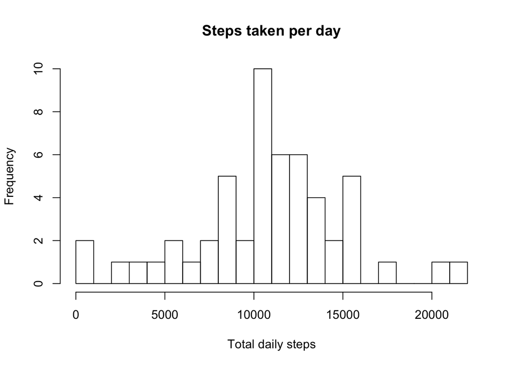

```r
hist(tapply(steps, date, sum), xlab = "Total daily steps", breaks = 20,
    main = "Steps taken per day")
```

But I will like to calculate the mean and media of everyday to do so i will :

```r
library(stats)
sum <-  tapply(steps, date,sum)
mean(sum,na.rm = TRUE)
```

```
## [1] 10766.19
```

```r
median(sum,na.rm = TRUE)
```

```
## [1] 10765
```

The question was:

Make a time series plot (i.e. type = “l”) of the 5-minute interval (x-axis) and the average number of steps taken, averaged across all days (y-axis)

Which 5-minute interval, on average across all the days in the dataset, contains the maximum number of steps?

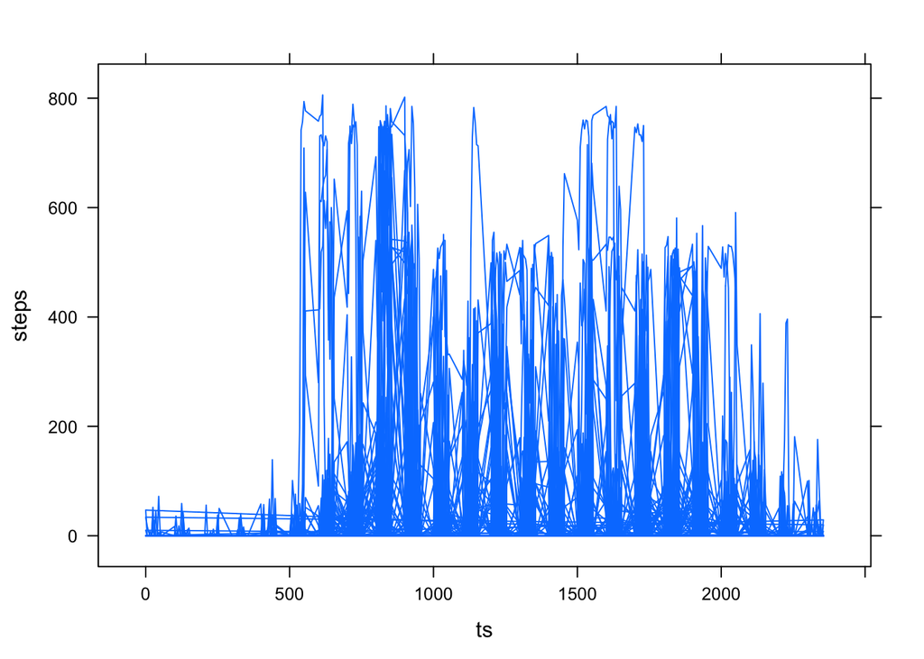

```r
ts <- ts(activity$interval,frequency=5)
library(lattice)
 xyplot(steps ~ ts, activity,
        type = "l",na.rm = TRUE)
```

Noe lets find out in which interval there is the highest mean.

```r
mean_interval <- as.numeric(tapply(steps,activity$interval, mean, na.rm = TRUE))
interval_ordered <-  activity$interval[order(mean_interval, decreasing = TRUE)]
head(interval_ordered)
```

```
## [1] 835 840 850 845 830 820
```

We can see that the maximun average steps is in the 835 interval There are many missing values but how can i measure that?

```r
summary(activity)
```

```
##      steps                date          interval
##  Min.   :  0.00   2012-10-01:  288   Min.   :   0.0
##  1st Qu.:  0.00   2012-10-02:  288   1st Qu.: 588.8
##  Median :  0.00   2012-10-03:  288   Median :1177.5
##  Mean   : 37.38   2012-10-04:  288   Mean   :1177.5
##  3rd Qu.: 12.00   2012-10-05:  288   3rd Qu.:1766.2
##  Max.   :806.00   2012-10-06:  288   Max.   :2355.0
##  NA's   :2304     (Other)   :15840
```

```r
## I can get there the missing vaulues but if i call the folowing function i will know the percentage.
 mean (is.na(activity))
```

```
## [1] 0.04371585
```

Now lets fill those missing values with the 0 value

```r
nactivity <- activity
head(activity)
```

```
##   steps       date interval
## 1    NA 2012-10-01        0
## 2    NA 2012-10-01        5
## 3    NA 2012-10-01       10
## 4    NA 2012-10-01       15
## 5    NA 2012-10-01       20
## 6    NA 2012-10-01       25
```

```r
nsteps <- nactivity [,1]
ndate <- nactivity [,2]
ninterval <-  nactivity [,3]
nactivity[is.na(nactivity)] <- 0
mean (is.na(nactivity))
```

```
## [1] 0
```

Now we have a first activity which shows our first data base, and the activity database with the na ’s filled in.

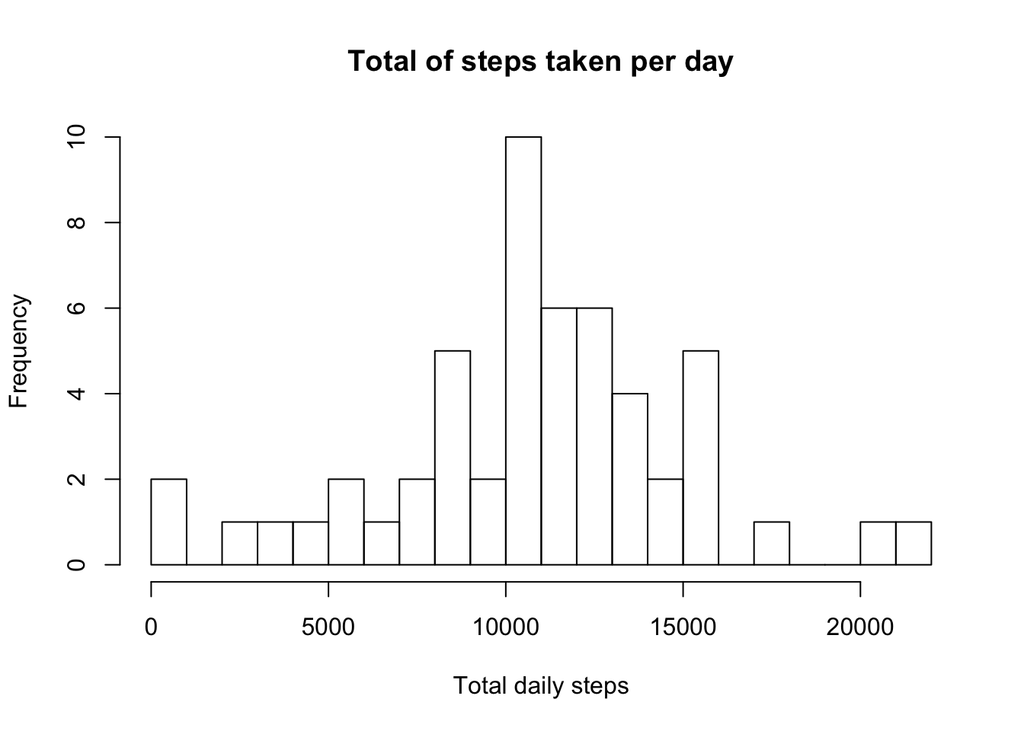

```r
library(graphics)
hist(tapply(nsteps, ndate ,sum), xlab = "Total daily steps", breaks = 20, main = "Total of steps taken per day")
```

```r
sum_n <-tapply(nsteps, ndate, sum)
head(sum_n,na.rm = TRUE)
```

```
## 2012-10-01 2012-10-02 2012-10-03 2012-10-04 2012-10-05 2012-10-06
##         NA        126      11352      12116      13294      15420
```

Now lets subset the data in week days and weekends

```r
date<- as.Date(date, format = "%Y-%m-%d")
```

```r
nactivity$day.type <- c("weekend", "weekday", "weekday", "weekday", "weekday", "weekday", "weekend")[as.POSIXlt(nactivity$date)$wday + 1]
nactivity$day.type <- as.factor(nactivity$day.type)
weekday <- nactivity[nactivity$day.type == "weekday", ]
weekend <- nactivity[nactivity$day.type =="weekend", ]
weekday.means <- as.numeric(tapply(weekday$steps, weekday$interval, mean))
weekend.means <- as.numeric(tapply(weekend$steps, weekend$interval, mean))
```

Here is the plot

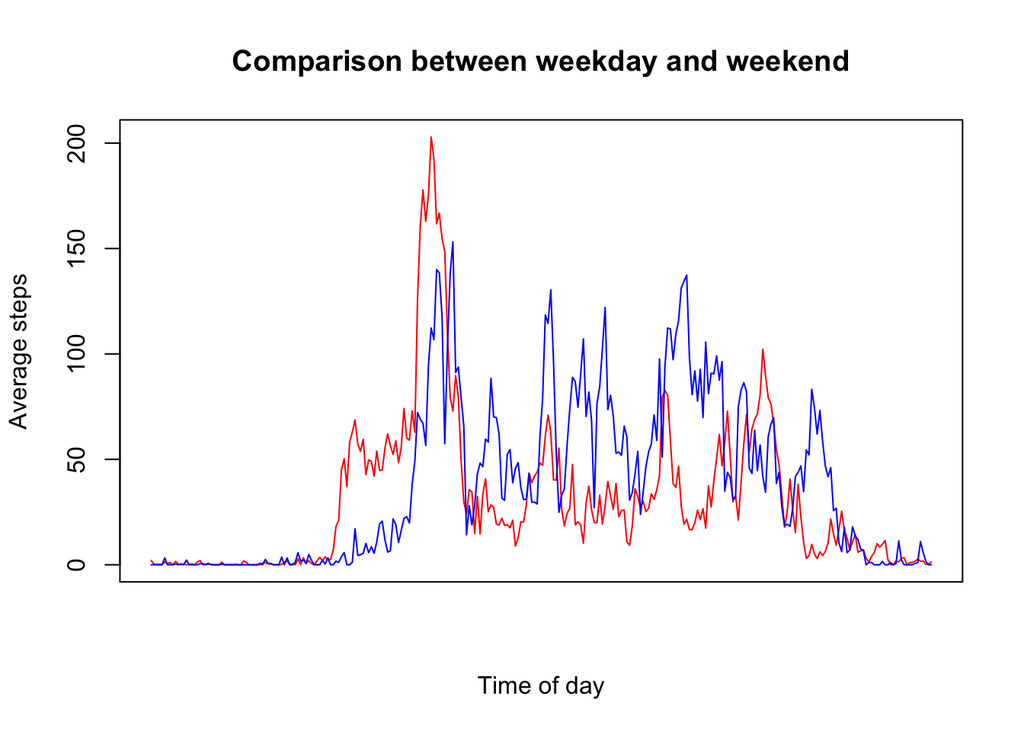

```r
plot( weekday.means, type = "l",
     col = "red", ylab = "Average steps", xlab = "Time of day", main = "Comparison between weekday and weekend",
     xaxt = "n")
lines(weekend.means, type = "l",  col = "blue")
legend(1500, 230, c("Weekend", "Weekday "), lty = c(1, 1), lwd = c(1, 1), col = c("blue", "red"))
```